# Building blocks

Boran Zhai

2025-12-22

# Buidling Blocks (getting started and best practices)

this code does variable assignments!

```r
x = runif(n = 20)    # Generate 20 random numbers
y = c(1,3,17,25)

mean(x)
```

```
## [1] 0.3837885
```

```r
var(x)
```

```
## [1] 0.06216552
```

## data frames

tibble() # create a dataframe

#### First example of dataframe

```r
library(tidyverse)

example_df = tibble(
  vec_numeric = 1:4,
  vec_char = c("Jack","Jeff","Lily","Sam"),
  vec_factor = factor(c("male","male","famale","male"))
)

example_df
```

```
## # A tibble: 4 × 3
##   vec_numeric vec_char vec_factor
##         <int> <chr>    <fct>
## 1           1 Jack     male
## 2           2 Jeff     male
## 3           3 Lily     famale
## 4           4 Sam      male
```

## make a df; and some plots!!

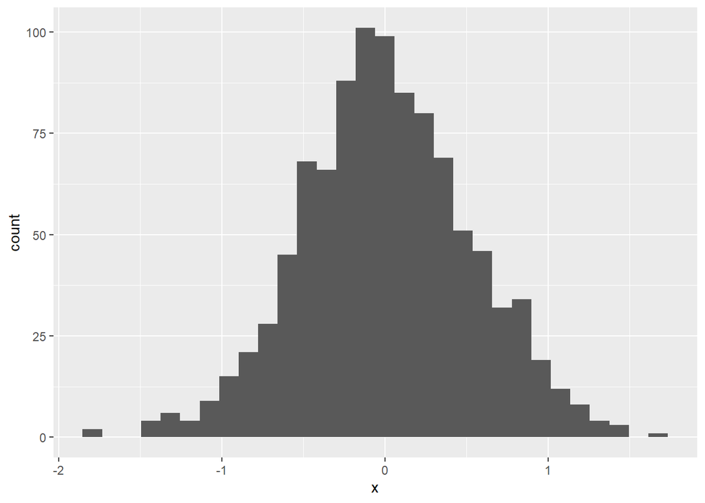

```r
plot_df = tibble(
  x = rnorm(1000, sd = 0.5),       # draw 1000 from normal distribution
  y = 1 + 2 * x + rnorm(1000),      # add noise
  y_quad = 1 + 2 * x - 3 * x ^ 2 +rnorm(1000)
  )

ggplot(plot_df, aes(x = x)) + geom_histogram()
```

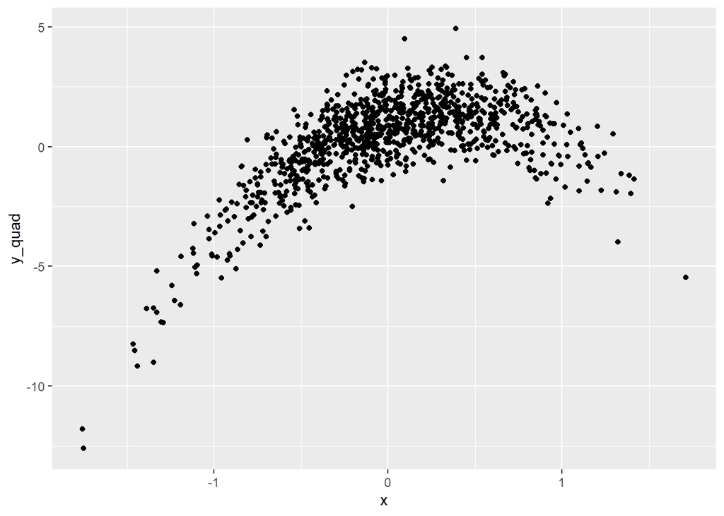

```r
# first thing is what data set, second is what I put in x-axis, and than going to say what kind of polt I want to draw

ggplot(plot_df, aes(x = x, y = y_quad)) + geom_point()
```

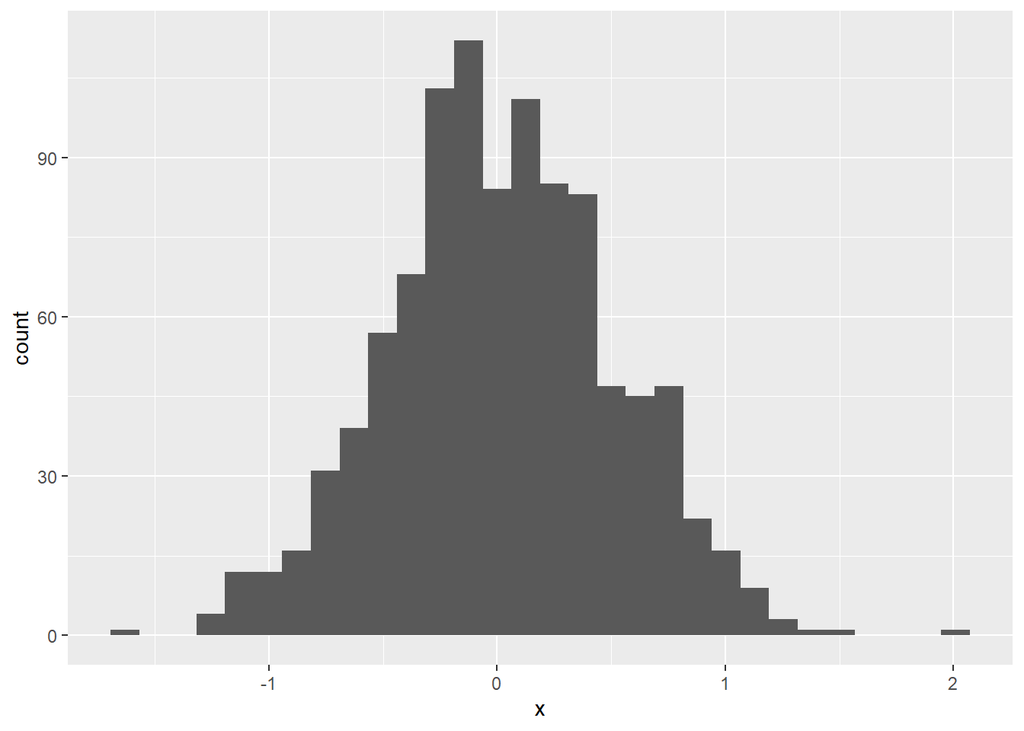

```r
plot_df = tibble(
  x = rnorm(1000, sd = 0.5),       # draw 1000 from normal distribution
  y = 1 + 2 * x + rnorm(1000),      # add noise
  y_quad = 1 + 2 * x - 3 * x ^ 2 +rnorm(1000)
  )

ggplot(plot_df, aes(x = x)) + geom_histogram()
```

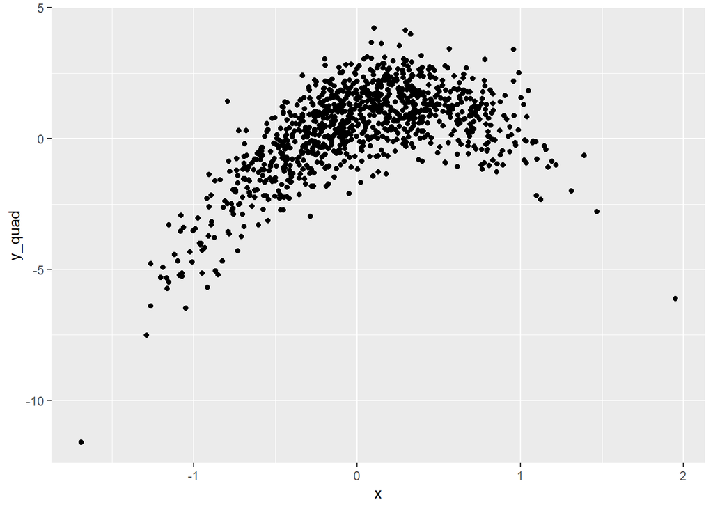

```r
ggplot(plot_df, aes(x = x, y = y_quad)) + geom_point()
```

# Writing with data

I am on R Markdown document!

## Section 1

Here’s a **code chunk** that samples from a *normal distribution*:

tips: “** **” make words bold, and “_ _” make words italicized

```r
samp = rnorm(100)
length(samp)
```

```
## [1] 100
```

## Section 2

I can take the mean of the sample, too! The mean is 0.0399054. (Inline R code)

### Code chunk options

give code chunk name in {r xxx};

echo = FALSE：code will be executed but not displayed; results are included.

eval = FALSE：code will be displayed but not executed; results are not included.;

include = FALSE: code won’t be executed or displayed;

message = FALSE：隐藏 package 启动等 message;

warning = FALSE：隐藏 warning 警告信息;

collapse = TRUE：把代码和输出合并显示在同一个代码块中output will be collapsed into a single block at shown at the end of the chunk.

results = “hide”：代码运行，但文本输出不显示（图还会显示）;

fig.show = “hide”：代码运行，但图不显示（文本结果还显示）;

fig.width = 6：设置图的宽度（英寸）; fig.height = 4：设置图的高度（英寸）;

fig.cap = “…”：给图加 caption（论文/报告常用）;

cache = TRUE：缓存运行结果，加快重新 knit;

error = TRUE：即使出错也继续 knit 文档. errors in code will stop rendering when FALSE; errors in code will be printed in the doc when TRUE. The default is FALSE and you should almost never change it;

child = “other.Rmd”：把另一个 Rmd 当子文档插入;

out.width = “70%”：控制图在页面中的显示宽度

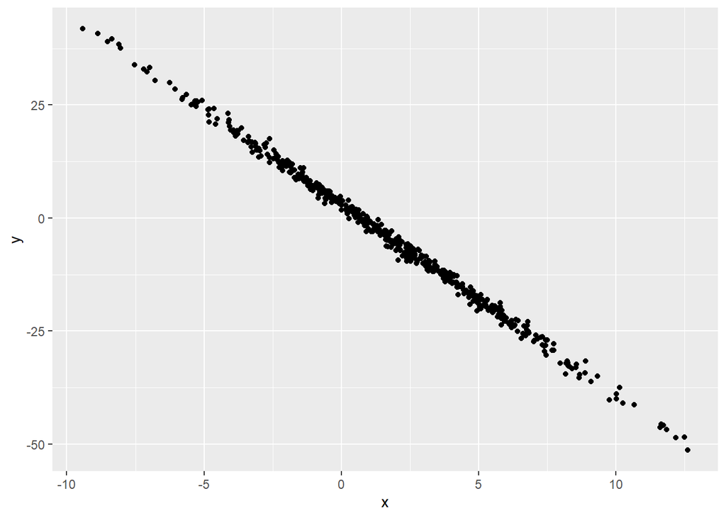

This plot is really great! It shows a linear relation just as expected.

The data frame has 500 rows. (Inline R code)

### Formatting text

section heading: # ## ### ####

make things bold: **bold** or **bold**

italicized: *italic* or *italic*

`code`

superscript <sup>2</sup> 上标and subscript<sub>2</sub> 下标

Here is a list:

- Bulleted list item 1
- Item 2
  - Item 2a
  - Item 2b
1. Numbered list item 1
2. Item 2. The numbers are incremented automatically in the output.

Here is for links and images:

http://example.com

[R Markdown cheatsheet](https://r4ds.had.co.nz/r-markdown.html)

[figure not shown]

optional caption text

Here is a table:

| First Header | Second Header |
| --- | --- |
| Content Cell | Content Cell |
| Content Cell | Content Cell |

| Col 1 | Col 2 | Col 3 |
| --- | --- | --- |
| a | b | c |
| d | e | f |

> This is a block quote.